# Probability Distributions in R

Nathan Ormond

2025-03-08

# Probability Distributions in R

R provides powerful built-in functions for working with probability distributions. This document explores how to use these functions for various statistical tasks.

## Basic Structure and Naming Convention

For any probability distribution with base name `xxx`, R provides four functions:

| Prefix | Function | Example | Purpose |
| --- | --- | --- | --- |
| `d` | Density | `dnorm()` | Probability density function (PDF) or probability mass function (PMF) |
| `p` | Probability | `pnorm()` | Cumulative distribution function (CDF) |
| `q` | Quantile | `qnorm()` | Quantile function (inverse CDF) |
| `r` | Random | `rnorm()` | Generate random samples from the distribution |

> **Note**: This consistent naming pattern applies to all probability distributions in R, making it straightforward to work with any distribution once you understand the pattern.

## Common Distributions

Below is a table of some common distributions available in R:

| Distribution | R Base Name | Required Parameters |
| --- | --- | --- |
| Normal | `norm` | `mean`, `sd` |
| Binomial | `binom` | `size` (n), `prob` (p) |
| Poisson | `pois` | `lambda` (λ) |
| Exponential | `exp` | `rate` (λ) |
| Uniform | `unif` | `min` (α), `max` (β) |
| Student’s t | `t` | `df` (degrees of freedom) |
| Chi-squared | `chisq` | `df` (degrees of freedom) |
| F | `f` | `df1`, `df2` (degrees of freedom) |
| Gamma | `gamma` | `shape`, `rate` or `scale` |
| Beta | `beta` | `shape1` (α), `shape2` (β) |

## Working with the Binomial Distribution

Let’s explore the binomial distribution with n = 20 and p = 0.2.

### Probability Mass Function (PMF)

Calculate the probability of getting exactly 5 successes:

```r
# P(X = 5)
dbinom(5, size = 20, prob = 0.2)
```

```
## [1] 0.1745595
```

We can visualise the entire PMF:

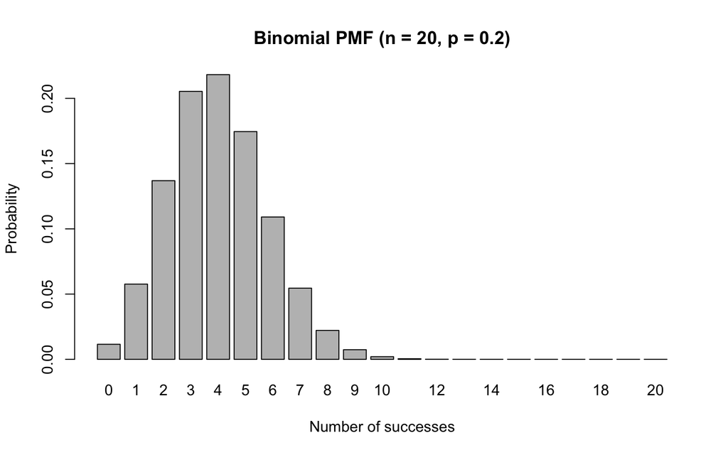

```r
x <- 0:20
pmf <- dbinom(x, size = 20, prob = 0.2)
barplot(pmf, names.arg = x, xlab = "Number of successes",
        ylab = "Probability",
        main = "Binomial PMF (n = 20, p = 0.2)")
```

> **Observation**: The distribution is slightly right-skewed with mode at x = 4.

### Cumulative Distribution Function (CDF)

Calculate the probability of getting at most 5 successes:

```r
# P(X ≤ 5)
pbinom(5, size = 20, prob = 0.2)
```

```
## [1] 0.8042078
```

Calculate the probability of getting more than 5 successes:

```r
# P(X > 5) = 1 - P(X ≤ 5)
1 - pbinom(5, size = 20, prob = 0.2)
```

```
## [1] 0.1957922
```

```r
# Alternative using lower.tail parameter
pbinom(5, size = 20, prob = 0.2, lower.tail = FALSE)
```

```
## [1] 0.1957922
```

Let’s visualise the CDF:

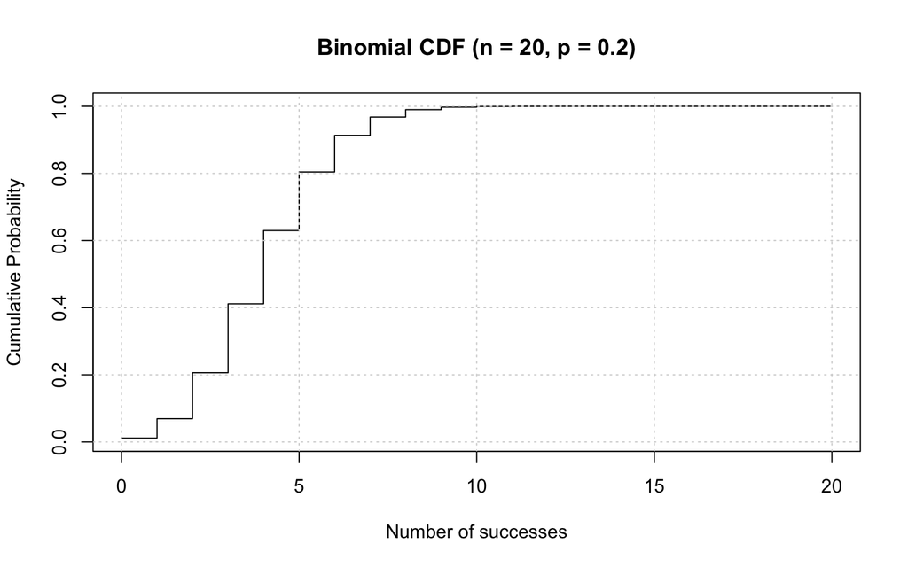

```r
cdf <- pbinom(x, size = 20, prob = 0.2)
plot(x, cdf, type = "s", xlab = "Number of successes",
     ylab = "Cumulative Probability",
     main = "Binomial CDF (n = 20, p = 0.2)")
grid()
```

### Quantile Function

Find the value such that the probability of getting at most that many successes is 0.5:

```r
# Find x where P(X ≤ x) = 0.5
qbinom(0.5, size = 20, prob = 0.2)
```

```
## [1] 4
```

We can find multiple quantiles at once:

```r
# Find 10th, 25th, 50th, 75th, and 90th percentiles
probs <- c(0.1, 0.25, 0.5, 0.75, 0.9)
qbinom(probs, size = 20, prob = 0.2)
```

```
## [1] 2 3 4 5 6
```

### Random Number Generation

Generate 10 random values from this binomial distribution:

```r
rbinom(10, size = 20, prob = 0.2)
```

```
##  [1] 3 5 3 6 7 1 4 6 4 4
```

Let’s visualise the distribution of a larger sample:

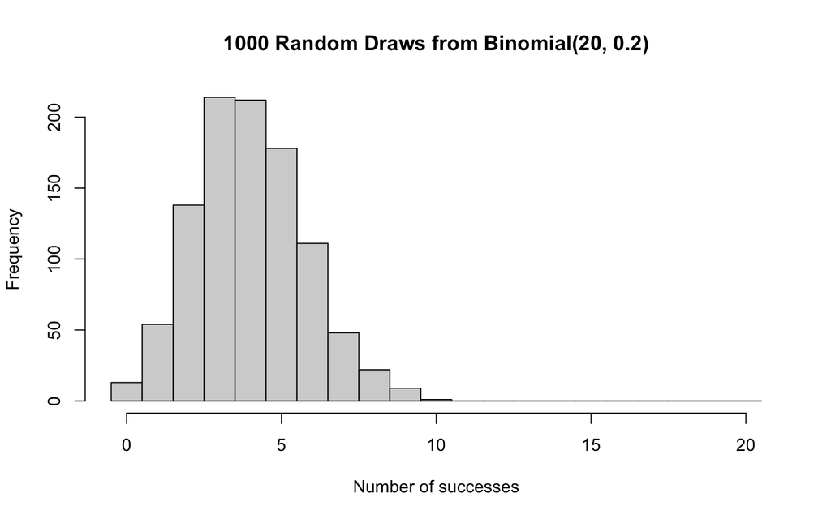

```r
random_sample <- rbinom(1000, size = 20, prob = 0.2)
hist(random_sample, breaks = seq(-0.5, 20.5, by = 1),
     xlab = "Number of successes",
     main = "1000 Random Draws from Binomial(20, 0.2)")
```

> **Note**: With a large enough sample, the histogram approximates the theoretical PMF.

## Working with the Normal Distribution

Let’s explore the normal distribution with mean = 70 and standard deviation = 5.

### Probability Density Function (PDF)

Calculate the height of the PDF at x = 70:

```r
dnorm(70, mean = 70, sd = 5)
```

```
## [1] 0.07978846
```

Visualise the PDF:

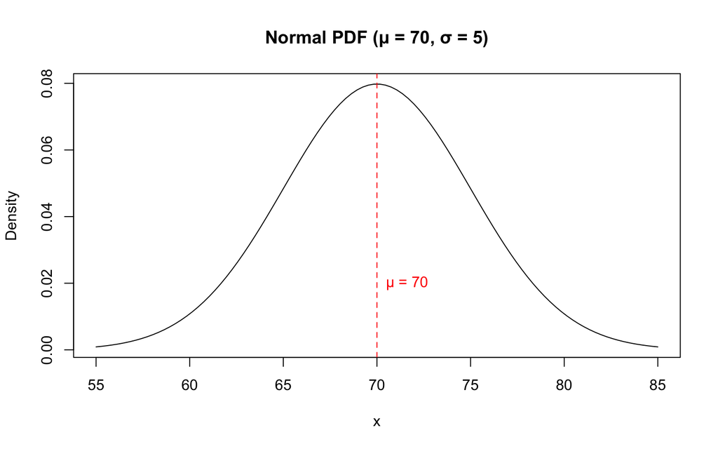

```r
x <- seq(55, 85, length.out = 100)
pdf <- dnorm(x, mean = 70, sd = 5)
plot(x, pdf, type = "l", xlab = "x", ylab = "Density",
     main = "Normal PDF (μ = 70, σ = 5)")
abline(v = 70, lty = 2, col = "red")
text(70, 0.02, "μ = 70", pos = 4, col = "red")
```

### Cumulative Distribution Function (CDF)

Calculate the probability that X ≤ 75:

```r
pnorm(75, mean = 70, sd = 5)
```

```
## [1] 0.8413447
```

Calculate the probability that X is between 65 and 75:

```r
pnorm(75, mean = 70, sd = 5) - pnorm(65, mean = 70, sd = 5)
```

```
## [1] 0.6826895
```

> **Insight**: This value is approximately 0.683, which corresponds to the probability within one standard deviation of the mean (the 68-95-99.7 rule).

Visualise the CDF:

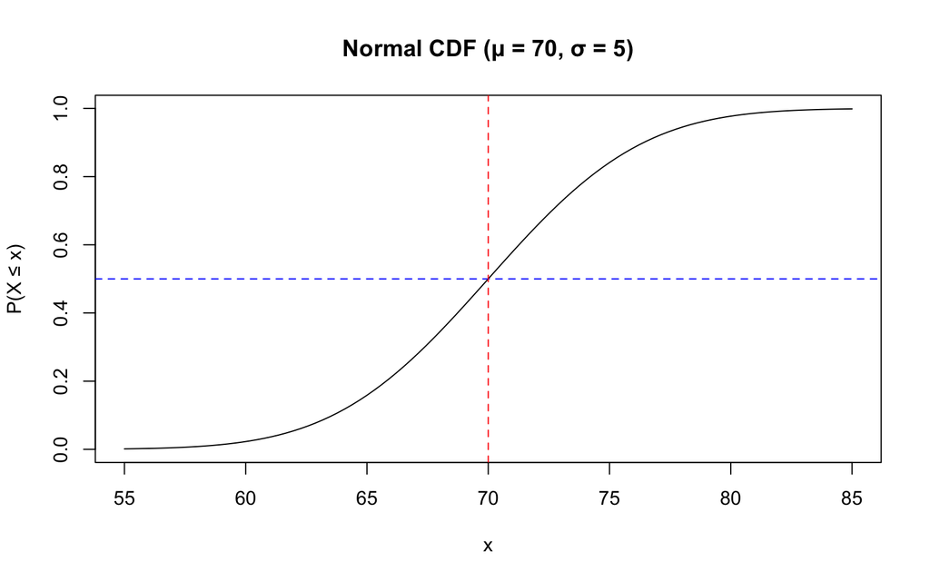

```r
cdf <- pnorm(x, mean = 70, sd = 5)
plot(x, cdf, type = "l", xlab = "x", ylab = "P(X ≤ x)",
     main = "Normal CDF (μ = 70, σ = 5)")
abline(h = 0.5, lty = 2, col = "blue")
abline(v = 70, lty = 2, col = "red")
```

### Quantile Function

Find the 25th, 50th, and 75th percentiles:

```r
qnorm(c(0.25, 0.5, 0.75), mean = 70, sd = 5)
```

```
## [1] 66.62755 70.00000 73.37245
```

### Random Number Generation

Generate 10 random values from this normal distribution:

```r
rnorm(10, mean = 70, sd = 5)
```

```
##  [1] 69.52426 65.52026 59.64624 70.75060 69.60394 69.51315 71.08076 74.41233
##  [9] 71.02799 66.91782
```

Visualise the distribution of a large sample:

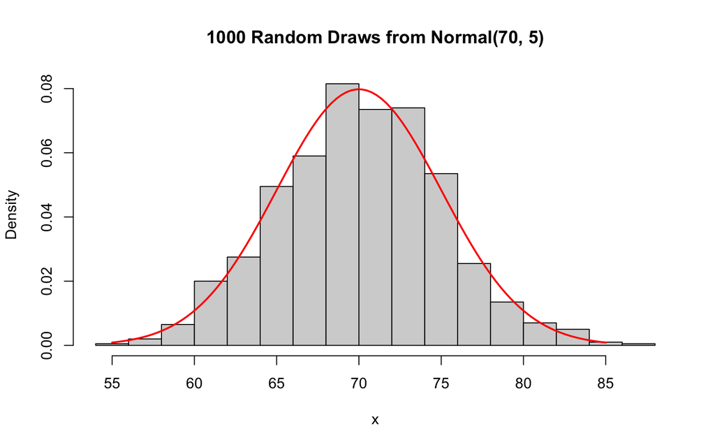

```r
random_sample <- rnorm(1000, mean = 70, sd = 5)
hist(random_sample, breaks = 20, probability = TRUE,
     xlab = "x", main = "1000 Random Draws from Normal(70, 5)")
lines(x, dnorm(x, mean = 70, sd = 5), col = "red", lwd = 2)
```

## Comparing Multiple Distributions

### Different Parameters of the Same Distribution

Let’s compare normal distributions with different parameters:

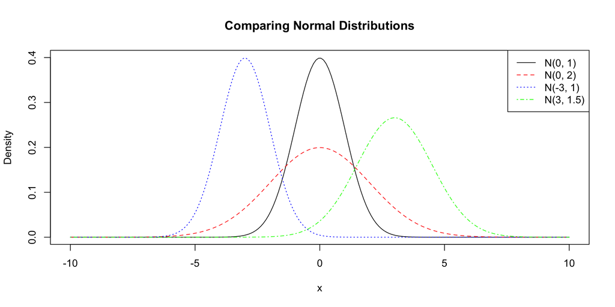

```r
x <- seq(-10, 10, length.out = 200)
plot(x, dnorm(x, mean = 0, sd = 1), type = "l",
     xlab = "x", ylab = "Density",
     main = "Comparing Normal Distributions",
     ylim = c(0, 0.4))
lines(x, dnorm(x, mean = 0, sd = 2), col = "red", lty = 2)
lines(x, dnorm(x, mean = -3, sd = 1), col = "blue", lty = 3)
lines(x, dnorm(x, mean = 3, sd = 1.5), col = "green", lty = 4)
legend("topright",
       legend = c("N(0, 1)", "N(0, 2)", "N(-3, 1)", "N(3, 1.5)"),
       col = c("black", "red", "blue", "green"),
       lty = c(1, 2, 3, 4))
```

### Different Types of Distributions

Let’s compare several different types of distributions:

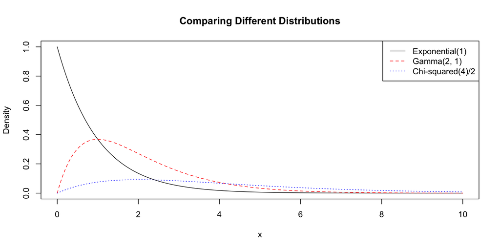

```r
x <- seq(0, 10, length.out = 200)
plot(x, dexp(x, rate = 1), type = "l",
     xlab = "x", ylab = "Density",
     main = "Comparing Different Distributions",
     ylim = c(0, 1))
lines(x, dgamma(x, shape = 2, rate = 1), col = "red", lty = 2)
lines(x, dchisq(x, df = 4)/2, col = "blue", lty = 3)
legend("topright",
       legend = c("Exponential(1)", "Gamma(2, 1)", "Chi-squared(4)/2"),
       col = c("black", "red", "blue"),
       lty = c(1, 2, 3))
```

## Practical Application: Calculating Probabilities and Critical Values

### Finding Critical Values for Hypothesis Testing

For a two-tailed test with significance level α = 0.05:

```r
# Critical values for standard normal distribution
alpha <- 0.05
qnorm(alpha/2, lower.tail = FALSE)  # upper critical value
```

```
## [1] 1.959964
```

```r
qnorm(alpha/2)  # lower critical value
```

```
## [1] -1.959964
```

```r
# Critical value for t-distribution with 10 degrees of freedom
qt(alpha/2, df = 10, lower.tail = FALSE)
```

```
## [1] 2.228139
```

### Calculating p-values

If we observed a t-statistic of 2.5 with 10 degrees of freedom:

```r
# Two-tailed p-value
2 * pt(2.5, df = 10, lower.tail = FALSE)
```

```
## [1] 0.03144684
```

### Confidence Intervals

95% confidence interval for a normal distribution with known standard deviation:

```r
mean_value <- 100
std_error <- 15
n <- 30
standard_error <- std_error / sqrt(n)

# 95% confidence interval
lower_bound <- mean_value + qnorm(0.025) * standard_error
upper_bound <- mean_value + qnorm(0.975) * standard_error
c(lower_bound, upper_bound)
```

```
## [1]  94.63242 105.36758
```

## Combining with Data Analysis

Let’s generate some data and check if it follows a normal distribution:

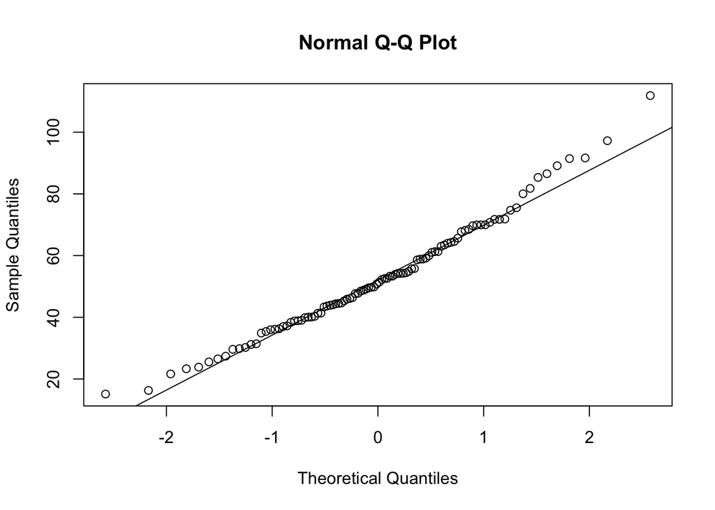

```r
# Generate slightly non-normal data
data <- rnorm(100, mean = 50, sd = 10)^2/50

# Q-Q plot
qqnorm(data)
qqline(data)
```

```r
# Shapiro-Wilk normality test
shapiro.test(data)
```

```
##
##  Shapiro-Wilk normality test
##
## data:  data
## W = 0.98114, p-value = 0.1628
```

## Advanced: Fitting Distributions to Data

Let’s generate data from a gamma distribution and then estimate its parameters:

```r
# Generate data from Gamma(shape=2, rate=0.5)
true_shape <- 2
true_rate <- 0.5
data <- rgamma(1000, shape = true_shape, rate = true_rate)

# Calculate method of moments estimators
sample_mean <- mean(data)
sample_var <- var(data)

shape_estimate <- sample_mean^2 / sample_var
rate_estimate <- sample_mean / sample_var

cat("True parameters: shape =", true_shape, ", rate =", true_rate, "\n")
```

```
## True parameters: shape = 2 , rate = 0.5
```

```r
cat("Estimated parameters: shape =", shape_estimate, ", rate =", rate_estimate, "\n")
```

```
## Estimated parameters: shape = 2.084805 , rate = 0.5259941
```

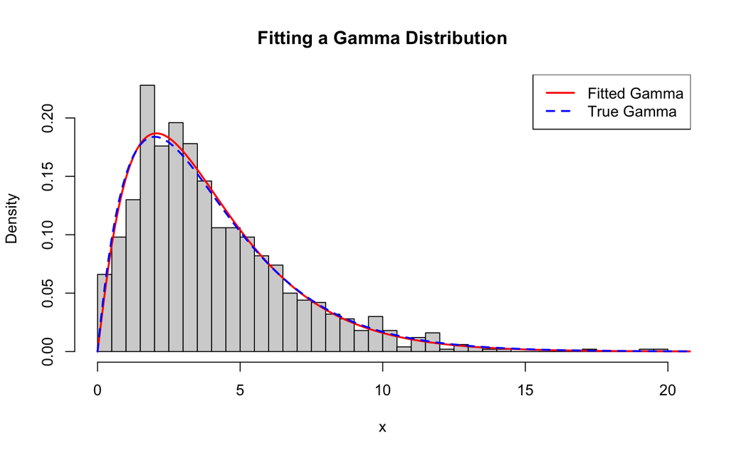

```r
# Plot the data with the fitted distribution
hist(data, breaks = 30, probability = TRUE,
     main = "Fitting a Gamma Distribution",
     xlab = "x")

x <- seq(0, max(data) + 5, length.out = 200)
lines(x, dgamma(x, shape = shape_estimate, rate = rate_estimate),
      col = "red", lwd = 2)
lines(x, dgamma(x, shape = true_shape, rate = true_rate),
      col = "blue", lwd = 2, lty = 2)
legend("topright",
       legend = c("Fitted Gamma", "True Gamma"),
       col = c("red", "blue"),
       lty = c(1, 2),
       lwd = c(2, 2))
```

## Conclusion

R’s built-in distribution functions provide powerful tools for probability calculations, statistical inference, and data analysis. The consistent naming convention (`d`, `p`, `q`, `r` prefixes) makes it easy to work with any probability distribution once you understand the pattern.

Some key points to remember:

1. For discrete distributions, the `d` functions give probabilities, while for continuous distributions, they give densities (not probabilities).
2. All distribution functions are vectorized, which enables efficient computation.
3. Always set a seed for reproducibility when generating random numbers.
4. Pay careful attention to the specific parameters required by each distribution.
5. Visualising distributions helps build intuition about their properties.

> **Final note**: Understanding these distribution functions is fundamental to performing statistical analysis in R. They form the foundation for hypothesis testing, confidence intervals, simulation studies, and many other statistical techniques.